# Bengaluru Metro

Ravi Gadepalli

# 1 System-Wide Characteristics

## 1.1 Hourly Trends: Weekdays vs Public Holidays on Smart Cards

The public holidays include Moharam(9), RakshaBandhan (11), Independence Day (15), Janmashtami(19), Ganesh Chaturthi (31).

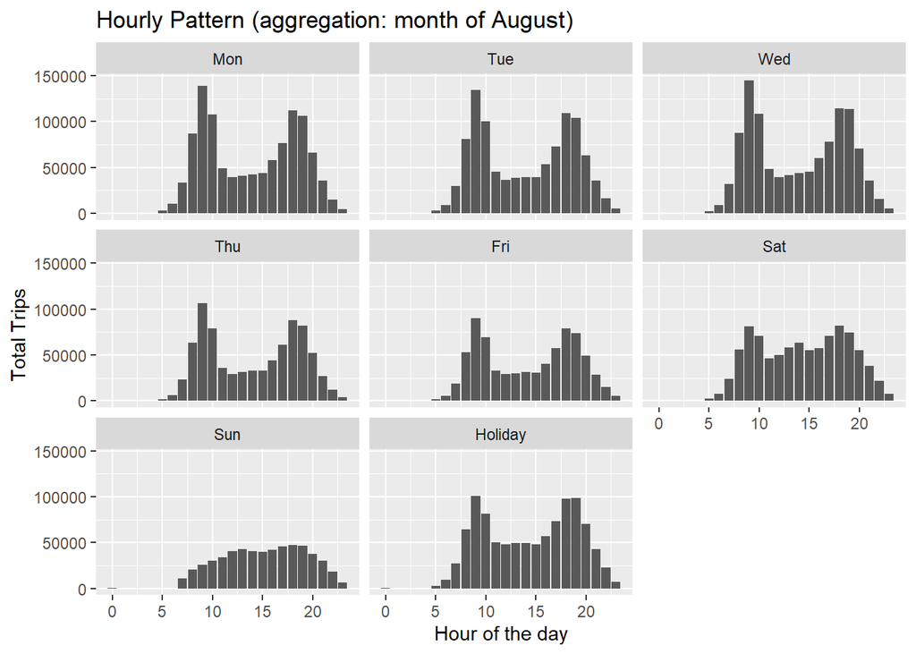

## 1.2 Peak vs Off Peak: Weekdays vs Public Holidays on Smart Cards

Morning Peak is 08:00-10:00 hrs, Evening Peak is 16:00-19:00 hrs

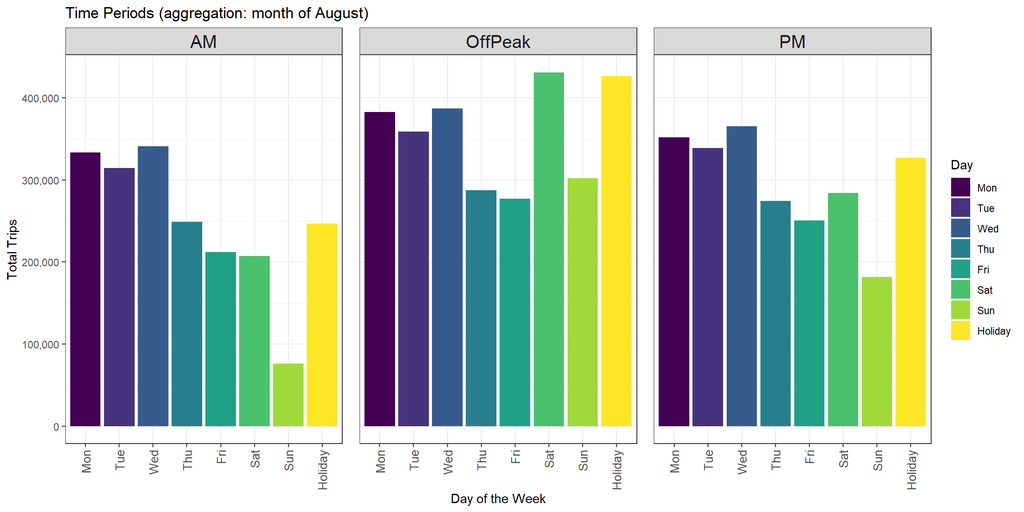

## 1.3 Hourly Trends: Weekdays vs Public Holidays on Tokens

The public holidays include Moharam(9), RakshaBandhan (11), Independence Day (15), Janmashtami(19), Ganesh Chaturthi (31).

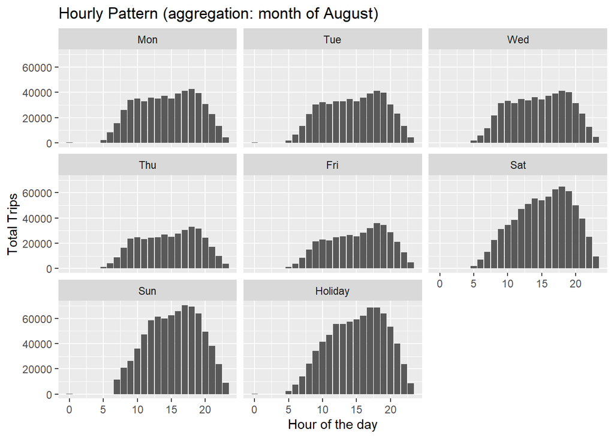

## 1.4 Peak vs Off Peak: Weekdays vs Public Holidays on Tokens

Morning Peak is 08:00-10:00 hrs, Evening Peak is 16:00-19:00 hrs

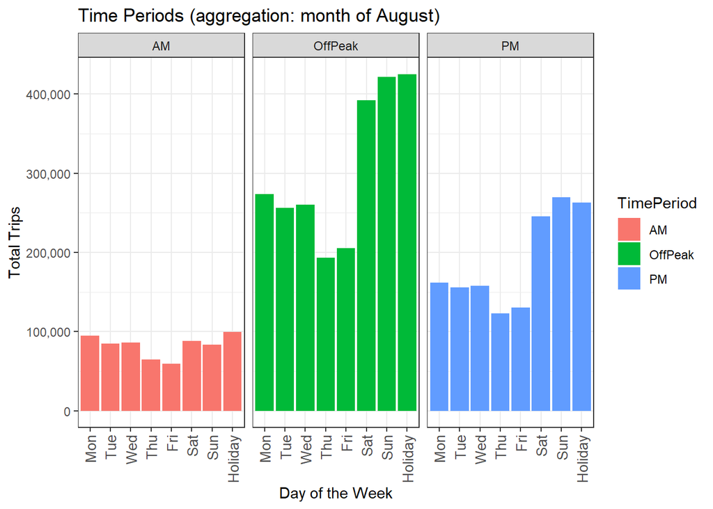

# 2 Line Based Characteristics

## 2.1 Hourly Trends: Weekdays vs Public Holidays on Smart Cards

The public holidays include Moharam(9), RakshaBandhan (11), Independence Day (15), Janmashtami(19), Ganesh Chaturthi (31).

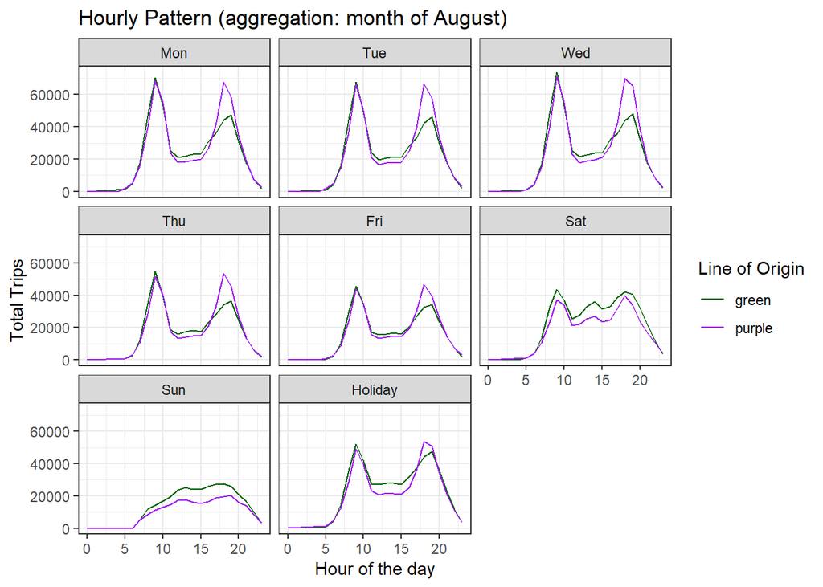

## 2.2 Peak vs Off Peak: Weekdays vs Public Holidays on Smart Cards

Morning Peak is 08:00-10:00 hrs, Evening Peak is 16:00-19:00 hrs

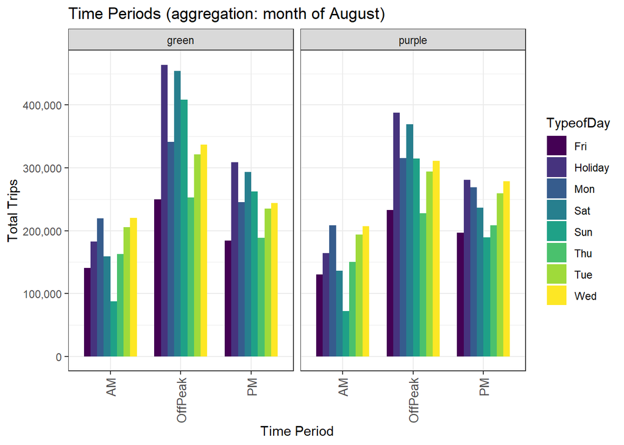

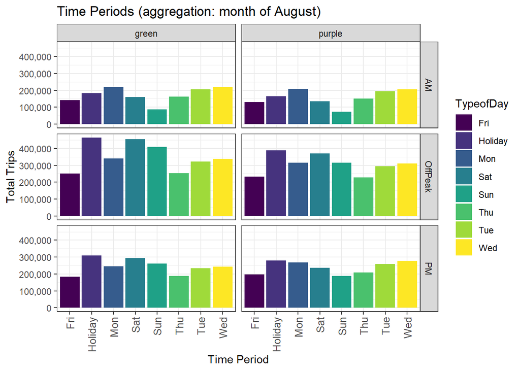

## 2.3 Hourly Trends: Weekdays vs Public Holidays on Tokens

The public holidays include Moharam(9), RakshaBandhan (11), Independence Day (15), Janmashtami(19), Ganesh Chaturthi (31).

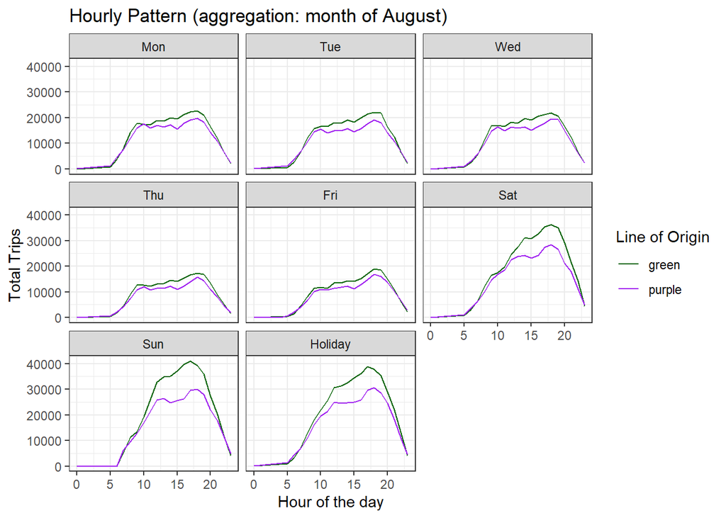

## 2.4 Peak vs Off Peak: Weekdays vs Public Holidays on Tokens

Morning Peak is 08:00-10:00 hrs, Evening Peak is 16:00-19:00 hrs

[figure not shown]

# 3 Peak flows on weekdays

## 3.1 Morning Peak Hour Flows

[interactive chart not shown]

## 3.2 Evening Peak Hour Flows

[interactive chart not shown]